# Reproducible research

## Whitaker’s matrix of reproducibility

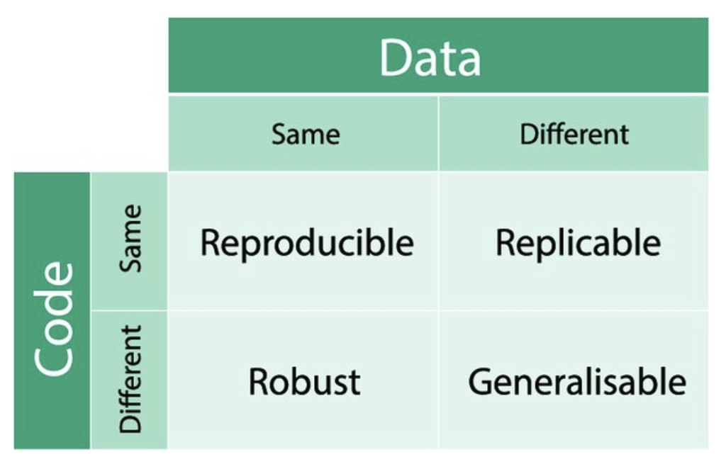

Kirstie Whitaker, University of Cambridge, Creative Commons Attribution license [CC-BY 4.0](https://creativecommons.org/licenses/by/4.0/).

## file management in general

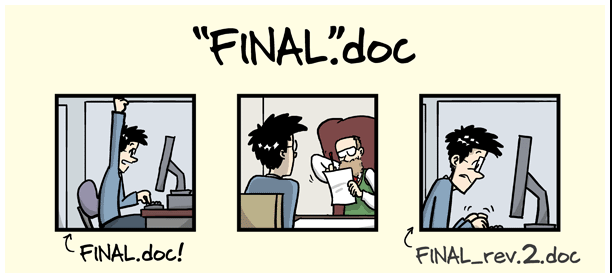

http://phdcomics.com/comics.php?f=1531

## Reproducible

Suppose you share your data with someone. Would they come to the same results and conclusions?

Should they?

What would they need to replicate your results?

## Reproducible

Results and conclusions depend on more than data:

- information about the data (meta data)
- outlier selection
- choices in analyses
- context
- interpretations
- versions of software used
- …

Thus, whole project needs to be clear and sharable, not just the data.

## Example: same data, other conclusions

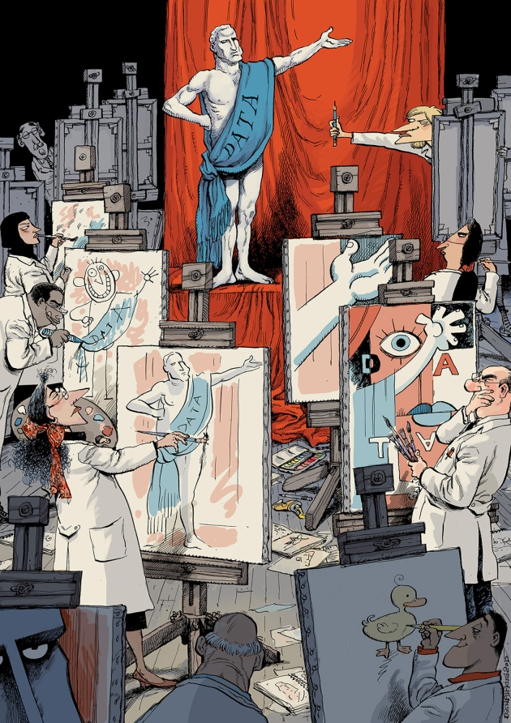

Silberzahn R, Uhlmann EL. Crowdsourced research: Many hands make tight work. *Nature*. 2015 Oct 8;526(7572):189-91.

doi: 10.1038/526189a.

PMID: 26450041.

## Example: same data, other conclusions

- 29 research groups got the same question, with the same dataset to solve it.
- Are football (soccer) referees more likely to give red cards to players with dark skin than to players with light skin?”

[figure not shown]

Mario Balotelli, playing for Manchester City, is shown a red card during a match against Arsenal. (Michael Regan/Getty)

## Example: same data, other conclusions

- They could analyse the data, and hand in their results and analysis method
- all 29 methods were distributed to all the other groups anonymously
- all groups could then alter their analyses if they wanted
- and discuss what would be the best method.

Example issues that were brought up:

- Is the age of a player a factor? Position on the field? Where the soccer team is from? How many yellow cards a player got previously? Which players are outliers? What kind of statistics should be used?

## Example: same data, other conclusions

- The research groups could not reach concensus about what would be “the correct solution”
- 20 groups found a significant effect, 9 did not.

## Example: same data, other conclusions

[figure not shown]

results Silberzahn & Uhlmann 2015

## Reproducible folder structure

```
old_laptop/wrong_structure
├── courses
├── ethical approval
├── failed projects
├── images
├── manuscripts
│   ├── me_et al , 2020_v01 - Copy.docx
│   ├── me_et al , 2020_v02.docx
│   └── me_et al about A, 2020_v03_final_final.docx
├── presentations
├── project A
│   ├── Data files 001
│   ├── Project Documentation
│   ├── Volunteer responses
│   ├── analyses
│   └── revision
│       ├── new analyses
│       ├── new figs
│       └── replies to reviewers
└── protocols
```

## Reproducible folder structure

drawbacks:

1. lose files, or the link between files.
2. Things will change.

## Reproducible folder structure

1. **project = folder** .
2. **consistent folder structure**
3. **Do not deep nest folders**
4. **Keep information about the data, close to the data**.
5. **Store each dataset in its own sub-folder.**
6. **Do not change file names or move them.**
7. **Do not manually edit data source files.**
8. **In code, use relative paths**

## Reproducible folder structure

```
new_laptop/better_example_structure
├── courses
├── project A
│   ├── analyses
│   │   ├── code
│   │   ├── data
│   │   └── data_raw
│   │       └── Volunteer responses
│   ├── documentation
│   ├── ethical approval
│   ├── images
│   ├── manuscript
│   │   ├── me_et al , 2020.docx
│   │   ├── version 1
│   │   └── version 2
│   ├── methods
│   │   └── protocols
│   └── presentations
├── project B
└── project C
```

## Exercise A1

- Look at your own folder structure and plan to fix it
- Breakout rooms, groups of 3

back here in 15 minutes